# Introduction to Data Analysis in R

12th January 2017

## Overview

- Frequentist analysis in R
  - t tests & ANOVAs
  - Regression
  - Mixed effect models
- Bayesian analysis in R
  - Bayes Factor
  - Bayesian estimation

## The fake data

### Dataset 1

```r
df1
```

```
## # A tibble: 120 × 6
##        id   year  school memory_score attention_score attainment
##    <fctr> <fctr>  <fctr>        <dbl>           <dbl>      <dbl>
## 1   ppt_1    two school1     6.876389        21.29311  11.103184
## 2   ppt_2    two school2    12.277561        19.37442  13.733366
## 3   ppt_3    two school1     9.211224        17.66561  11.447986
## 4   ppt_4    two school2    18.267985        19.63014  13.103020
## 5   ppt_5    two school1    21.101087        13.89878  14.787214
## 6   ppt_6    two school2    12.166825        18.72081  13.313488
## 7   ppt_7    two school1     8.022262        23.81024   3.622945
## 8   ppt_8    two school2     5.557377        16.22446  10.851095
## 9   ppt_9    two school1    10.970423        19.47799  12.640163
## 10 ppt_10    two school2    11.339113        17.29095  15.572928
## # ... with 110 more rows
```

## The fake data

### Dataset 2

- 4 variables:
  - id: participant ID
  - n_correct: number of correct trials
  - rt: reaction time
  - condition: experimental condition

## The fake data

### Dataset 2

```r
df2
```

```
## # A tibble: 240 × 4
##        id n_correct        rt condition
##    <fctr>     <int>     <dbl>     <chr>
## 1   ppt_1        17 1292.8393  baseline
## 2   ppt_2        20 1116.0032  baseline
## 3   ppt_3        18 1563.9323  baseline
## 4   ppt_4        17 1425.5921  baseline
## 5   ppt_5        15 1245.9950  baseline
## 6   ppt_6        18  673.1109  baseline
## 7   ppt_7        16 1605.9124  baseline
## 8   ppt_8        17 1115.2844  baseline
## 9   ppt_9        21  909.9099  baseline
## 10 ppt_10        17 1258.7746  baseline
## # ... with 230 more rows
```

## A note on tibbles

- Tibbles, the data.frame format used by tidyverse packages (e.g. dplyr), don't work with some statistical packages (e.g. `ez`, `BayesFactor`)
  - All you have to do is convert your tibble to a data.frame with `as.data.frame()`
  - Do this in the call to a function to avoid changing your stored tibble
- `BayesFactor` also requires you to convert character columns into factors
  - Other packages are more forgiving on this

## Frequentist analysis in R

## Frequentist analysis in R

- There are function in base R for a lot of the stuff you'd want to do
- However, it sometimes easier to do things with a package

## Frequentist analysis in R

### t test

```r
t.test(formula = memory_score ~ year, data = df1, paired = FALSE)
```

```
##
##  Welch Two Sample t-test
##
## data:  memory_score by year
## t = 1.993, df = 117.98, p-value = 0.04857
## alternative hypothesis: true difference in means is not equal to 0
## 95 percent confidence interval:
##  0.009561505 2.986440290
## sample estimates:
## mean in group five  mean in group two
##           12.33129           10.83329
```

## Frequentist analysis in R

### t test

- Or if we had wide data

```r
t.test(x = memory_year2, y = memory_year5, data = df_wide, paired = FALSE)
```

- **Note:** R uses Welch's t-test as standard
  - See [here](http://daniellakens.blogspot.co.uk/2015/01/always-use-welchs-t-test-instead-of.html) for info on this

## Frequentist analysis in R

### An ANOVA warning

- There are multiple ways to calculate the sum of squares (SS) for an ANOVA
- The inbuilt `aov()` function uses Type I SS, which isn't what we usually want
- Typically we want Type III SS (e.g. this what SPSS uses)

## Frequentist analysis in R

### ANOVA

```r
library(ez)

ezANOVA(data = as.data.frame(df1), dv = attainment, wid = id, between = .(year, school),
        type = 3, detailed = FALSE)
```

```
## $ANOVA
##        Effect DFn DFd         F          p p<.05         ges
## 2        year   1 116 4.2190464 0.04222005     * 0.035094659
## 3      school   1 116 0.8066110 0.37098448       0.006905525
## 4 year:school   1 116 0.3366236 0.56290997       0.002893531
##
## $`Levene's Test for Homogeneity of Variance`
##   DFn DFd      SSn      SSd         F         p p<.05
## 1   3 116 2.261281 380.3794 0.2298658 0.8754344
```

## Frequentist analysis in R

### ANOVA

```r
ezANOVA(data = as.data.frame(df1), # data
        dv = attainment, # dependent variable
        wid = id, # subject ID
        between = .(year, school), # between subject factors
        type = 3, # type of SS
        detailed = FALSE) # detailed output?
```

```
## $ANOVA
##        Effect DFn DFd         F          p p<.05         ges
## 2        year   1 116 4.2190464 0.04222005     * 0.035094659
## 3      school   1 116 0.8066110 0.37098448       0.006905525
## 4 year:school   1 116 0.3366236 0.56290997       0.002893531
##
## $`Levene's Test for Homogeneity of Variance`
##   DFn DFd      SSn      SSd         F         p p<.05
## 1   3 116 2.261281 380.3794 0.2298658 0.8754344
```

## Frequentist analysis in R

### linear regression

```r
lm(attainment ~ memory_score + attention_score + year + school, data = df1) %>%
  summary()
```

## Frequentist analysis in R

### linear regression

```
##
## Call:
## lm(formula = attainment ~ memory_score + attention_score + year +
##     school, data = df1)
##
## Residuals:
##     Min      1Q  Median      3Q     Max
## -7.1020 -1.5864  0.1024  1.5569  5.2049
##
## Coefficients:
##                 Estimate Std. Error t value Pr(>|t|)
## (Intercept)      4.26750    1.09263   3.906 0.000159 ***
## memory_score     0.47500    0.04707  10.091  < 2e-16 ***
## attention_score  0.03750    0.04612   0.813 0.417856
## yeartwo          1.75396    0.38933   4.505  1.6e-05 ***
## schoolschool2    0.28525    0.38746   0.736 0.463105
## ---
## Signif. codes:  0 '***' 0.001 '**' 0.01 '*' 0.05 '.' 0.1 ' ' 1
##
## Residual standard error: 2.092 on 115 degrees of freedom
## Multiple R-squared:  0.4917, Adjusted R-squared:  0.4741
## F-statistic: 27.82 on 4 and 115 DF,  p-value: 3.685e-16
```

## Frequentist analysis in R

### linear regression

```r
library(lm.beta)

lm(attainment ~ memory_score + attention_score + year + school , data = df1) %>%
  lm.beta()
```

```
##
## Call:
## lm(formula = attainment ~ memory_score + attention_score + year +
##     school, data = df1)
##
## Standardized Coefficients::
##     (Intercept)    memory_score attention_score         yeartwo
##      0.00000000      0.68631433      0.05530162      0.30529034
##   schoolschool2
##      0.04965031
```

## Frequentist analysis in R

### logistic regression

```r
fit_logistic <- glm(cbind(n_correct, 30 - n_correct) ~ condition,
                     family = binomial(link = "logit"), data = df2) %>%
  summary()
```

## Frequentist analysis in R

### logistic regression

```r
fit_logistic$coefficients
```

```
##                     Estimate Std. Error   z value     Pr(>|z|)
## (Intercept)        0.3479118 0.03383892 10.281410 8.546754e-25
## conditioncog_load -0.3468007 0.04749930 -7.301175 2.852664e-13
```

```r
plogis(fit_logistic$coefficients[1,1] + fit_logistic$coefficients[2,1])
```

```
## [1] 0.5002778
```

## Frequentist analysis in R

### mixed effects models

```r
library(lme4)

(fit_mixed <- lmer(rt ~ condition + (1 | id), data = df2))
```

```
## Linear mixed model fit by REML ['lmerMod']
## Formula: rt ~ condition + (1 | id)
##    Data: df2
## REML criterion at convergence: 3398.566
## Random effects:
##  Groups   Name        Std.Dev.
##  id       (Intercept) 3.554e-07
##  Residual             2.991e+02
## Number of obs: 240, groups:  id, 120
## Fixed Effects:
##       (Intercept)  conditioncog_load
##            1509.1              205.5
```

## Frequentist analysis in R

### Online stuff

- A number of the resources discussed in my last talk also cover analysis
  - E.g. [Datacamp](https://www.datacamp.com/courses/topic:probablity_and_statistics)
- [Linear models in R](http://www.bodowinter.com/tutorial/bw_LME_tutorial1.pdf)
- [Mixed-effects models for repeated-measures ANOVA](http://www.uni-kiel.de/psychologie/rexrepos/posts/anovaMixed.html)
- [Basic mixed-effects models tutorial](http://www.bodowinter.com/tutorial/bw_LME_tutorial2.pdf)
- [Interactions and contrasts](http://genomicsclass.github.io/book/pages/interactions_and_contrasts.html)
- Forgot [R-bloggers](https://www.r-bloggers.com/) last time

## Frequentist analysis in R

### books and papers

- Paper on why we should use logisitics regression for accuracy data ([Jaeger, 2008](https://www.ncbi.nlm.nih.gov/pmc/articles/PMC2613284/))
- [Data Analysis Using Regression and Multilevel/Hierarchical Models](http://www.stat.columbia.edu/~gelman/arm/)

## Bayesian analysis

## Bayes Factors

- The ratio of the likelihood of our data under one model versus another.
  - E.g. null v.s. alternative
- Useful for things like quantifying evidence for the null

## Bayes Factor

### t test

```r
library(BayesFactor)

ttestBF(formula = memory_score ~ year, data = as.data.frame(df1), paired = FALSE)
```

```
## Bayes factor analysis
## --------------
## [1] Alt., r=0.707 : 1.151051 ±0%
##
## Against denominator:
##   Null, mu1-mu2 = 0
## ---
## Bayes factor type: BFindepSample, JZS
```

- **Note:** the frequentist equivalent of this analysis was significant

## Bayes Factor

### t test

```r
bf1 <- ttestBF(formula = attention_score ~ year,
               data = as.data.frame(df1), paired = FALSE)

1/bf1 # 1 / bf to get evidence for the null
```

```
## Bayes factor analysis
## --------------
## [1] Null, mu1-mu2=0 : 3.30978 ±0%
##
## Against denominator:
##   Alternative, r = 0.707106781186548, mu =/= 0
## ---
## Bayes factor type: BFindepSample, JZS
```

## Bayes Factor

### t test

```r
# posterior = TRUE gives us posterior samples instead of the standard Bf analysis

samples <- ttestBF(formula = attention_score ~ year, data = as.data.frame(df1),
                   paired = FALSE, posterior = TRUE, iterations = 5e04)
```

## Bayes Factor

### t test

```r
summary(samples)[1]
```

```
## $statistics
##                         Mean         SD     Naive SE Time-series SE
## mu                18.6248677  0.3905785 0.0017467202   0.0017467202
## beta (five - two) -0.6911446  0.7455256 0.0033340919   0.0033620220
## sig2              18.2651409  2.4019089 0.0107416632   0.0109332107
## delta             -0.1626449  0.1747553 0.0007815296   0.0007877683
## g                  3.1198691 70.6559162 0.3159828632   0.3159828632
```

## Bayes Factor

### t test

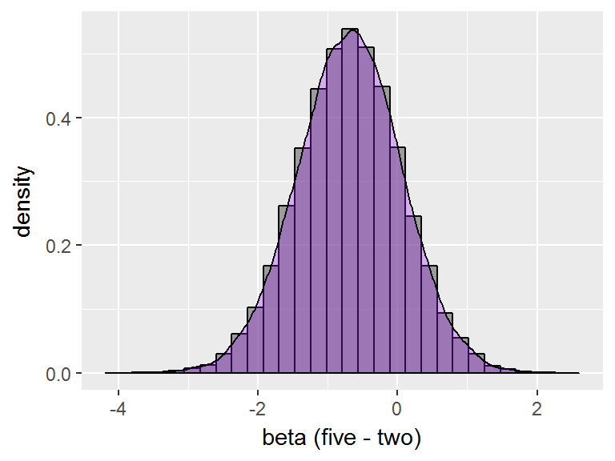

```r
samples_df <- as_data_frame(samples)

ggplot(data = samples_df, aes( x = `beta (five - two)`, y = ..density..)) +
  geom_histogram(colour = "black", fill = "gray30", alpha = 0.5) +
  geom_density(alpha = .3, fill = "purple")
```

## Bayes Factor

### base plots

[figure not shown]

```r
plot(samples)
```

## Bayes Factor

### ANOVA

```r
anovaBF(attainment ~ year + school, data = as.data.frame(df1), whichRandom = "id",
        iterations = 5e04) %>%
  head()
```

```
## Bayes factor analysis
## --------------
## [1] year                        : 1.301718  ±0%
## [2] year + school               : 0.3523725 ±0.84%
## [3] school                      : 0.2776426 ±0%
## [4] year + school + year:school : 0.1053211 ±1.66%
##
## Against denominator:
##   Intercept only
## ---
## Bayes factor type: BFlinearModel, JZS
```

## Bayes Factor

### Linear regression

```r
regressionBF(attainment ~ memory_score + attention_score, data = as.data.frame(df1)) %>%
  head() # gives the most likely model in order of likelihood
```

```
## Bayes factor analysis
## --------------
## [1] memory_score                   : 267972521036 ±0.01%
## [2] memory_score + attention_score : 69776983529  ±0%
## [3] attention_score                : 0.1961458    ±0%
##
## Against denominator:
##   Intercept only
## ---
## Bayes factor type: BFlinearModel, JZS
```

## Bayes Factor

### Linear regression

- Can't use `regressionBF()` for catergorical predictors

```r
lmBF(attainment ~ memory_score + attention_score + year + school,
     data = as.data.frame(df1))
```

```
## Bayes factor analysis
## --------------
## [1] memory_score + attention_score + year + school : 1.568884e+13 ±1.4%
##
## Against denominator:
##   Intercept only
## ---
## Bayes factor type: BFlinearModel, JZS
```

## Bayesian estimate

### Overview

- Specify probabilistic models to estimate parameter values
- Can write the whole model yourself (e.g. with Stan, JAGS, BUGS)
  - All of these have R packages associated with them
- Another option is to use the higher level package `rstanarm` (see also `brms`). This package uses syntax based on the `lme4` package
  - Easier to learn and read
  - Offers pre-compiled models for most of the stuff you'll want to do

## rstanarm

### linear regression

```r
library(rstanarm)

options(mc.cores = parallel::detectCores())

fit1 <- stan_lm(attainment ~ memory_score + attention_score + year + school,
                data = df1,
                prior = R2(location = 0.2)) # prior as R^2
```

## rstanarm

### linear regression

```r
fit1
```

```
## stan_lm(formula = attainment ~ memory_score + attention_score +
##     year + school, data = df1, prior = R2(location = 0.2))
##
## Estimates:
##                 Median MAD_SD
## (Intercept)     4.7    1.1
## memory_score    0.4    0.0
## attention_score 0.0    0.0
## yeartwo         1.6    0.4
## schoolschool2   0.3    0.4
## sigma           2.1    0.1
## log-fit_ratio   0.0    0.1
## R2              0.5    0.1
##
## Sample avg. posterior predictive
## distribution of y (X = xbar):
##          Median MAD_SD
## mean_PPD 11.5    0.3
##
## Observations: 120  Number of unconstrained parameters: 7
```

## rstanarm

### ShinyStan

[figure not shown]

```r
launch_shinystan(fit1)
```

## Bayesian analysis in R

### online resources

- `BayesFactor` [Manual](http://bayesfactorpcl.r-forge.r-project.org/)
- Understanding Bayes [blogs](https://alexanderetz.com/understanding-bayes/)
- `rstanarm` [vignettes](https://cran.r-project.org/web/packages/rstanarm/vignettes/rstanarm.html)

## Bayesian analysis in R

### books

- [Doing Bayesian Data Analysis](http://www.indiana.edu/~kruschke/DoingBayesianDataAnalysis/)
- [Statistical Rethinking: A Bayesian Course with Examples in R and Stan](http://xcelab.net/rm/statistical-rethinking/)
- [Bayesian Data Analysis](http://www.stat.columbia.edu/~gelman/book/)

## Misc tips

- Change the type of contrasts used
  - `options(contrasts=c('contr.sum', 'contr.sum'))`
  - Useful guide to contrast [here](http://www.ats.ucla.edu/stat/r/library/contrast_coding.htm)
- Remember the broom package from last time for cleaning up modelling outputs

## Your assignment

## The data

```
## # A tibble: 240 × 4
##       id condition  site memory_score
##    <chr>     <chr> <chr>        <dbl>
## 1  ppt_1    single    UK         14.1
## 2  ppt_1      dual    UK          6.8
## 3  ppt_2    single    UK         10.5
## 4  ppt_2      dual    UK          8.2
## 5  ppt_3    single    UK         17.1
## 6  ppt_3      dual    UK         11.9
## 7  ppt_4    single    UK         15.6
## 8  ppt_4      dual    UK          7.9
## 9  ppt_5    single    UK         13.2
## 10 ppt_5      dual    UK         14.3
## # ... with 230 more rows
```

## The columns

- **id:** participant ID
- **condition:** memory condition, either single or dual task
- **site:** where the data was collected (UK or US)
- **memory_score:** performance on a the memory task

## The questions

- Is there a difference in performance between the two conditions?
- Does it matter where the data was collected?
- Do condition and where the data was collected interact?
- Optional (advanced): does baseline performance vary by participant?

## Additional things to try

- Put the data is wide format
  - I.e. columns for UK_single, UK_dual, US_single, US_dual
- Make some plots

## Find the materials

- Head to https://github.com/eddjberry/intro-to-R-talks
  - The data is in the data folder